# M5: Path Reconstruction & Simulations

Day 4 — Behavior Analysis Part 1

Animal Movement Analyses for Ecologists | SYSU Shenzhen, July 2026

2026-07-21

*Created: 2026-07-13* | *Last updated: 2026-07-21*

## 1 Learning Objectives

By the end of this module you will be able to:

1. Make conditional predictions for animal locations based on the telemetry data and selected movement model, to get the most-likely-path taken by an individual.
2. Simulate paths from a defined movement model and sampling schedule, conditional on data (if provided).
3. Include parameter uncertainty in simulations by simulating a movement model from the sampling distribution of a defined movement model, conditional on data (if provided).

**Packages used:** `ctmm`

## 2 Background

Movement analyses, such as home-range estimation, speed estimation, revisitation, and integrated resource selection, are all conditional analyses that depend on models fit to our movement data. These models, like our continuous-time movement (autocorrelation) models aim to capture trends and summarize our data, such that they can be used to inform downstream analyses. With our movement models, we can interpolate to reconstruct animal paths, fill in gaps in our tracking data, and project into the future space use. Simulations conditioned on movement models have also been used to evaluate how much space an animal could have used; for example, how would an animal’s movement speed or home range size compare if there were no roads restricting their movement ([Noonan et al., 2022](https://doi.org/10.1111/acv.12728); [Mercer et al., 2026](https://doi.org/10.64898/2026.01.23.701409))?

In this module, we will walk through how to predict from a movement model, reconstruct a most-likely path, and generate simulations (generic and conditional) from movement models. We wrap up the module with an example case study on white-nosed coatis (*Nasua narica*) in Panama ([Kays & Hirsch, 2015](https://doi.org/10.5441/001/1.41076dq1)).

## 3 Data Preparation

To demonstrate, we will be using the African Buffalo (*Syncerus caffer*) dataset in `ctmm` for GPS-tagged buffalo in Kruger National Park, South Africa. First, let’s import, visualize, and perform model selection on our data to find the best-fit model for our predictions and simulations.

### 3.1 Import and Visualize Data

We will work with only one buffalo, Cilla, as an example.

```r
# Load ctmm package
library(ctmm)

# Load buffalo data from package
data(buffalo)
projection(buffalo) <- median(buffalo)  # center projection on median

names(buffalo)
```

```
## [1] "Cilla"  "Gabs"   "Mvubu"  "Pepper" "Queen"  "Toni"
```

```
## DOP values missing. Assuming DOP=1.
```

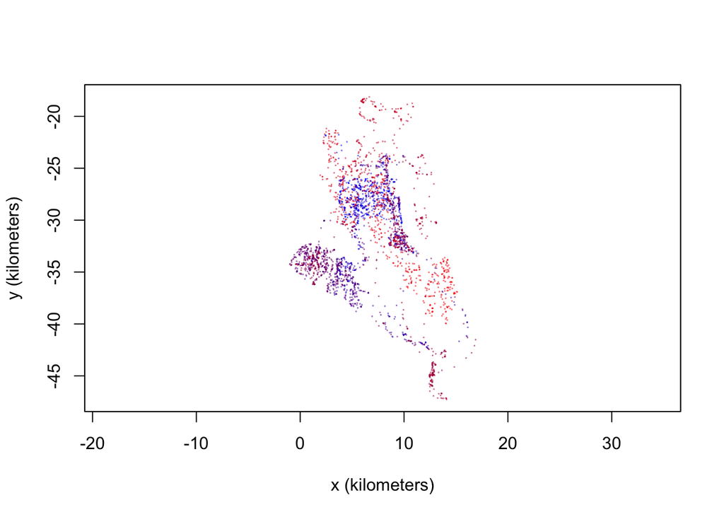

```r
# Subset to Cilla
DATA <- buffalo$Cilla
plot(DATA, col = color(DATA, by = "time"))
```

### 3.2 Model Selection

Remember that model selection can be slow, because multiple candidate models are fit. We have already run this process and saved the results in an R data file (“.rda”), which we can load in to save time.

```r
# Autocorrelation model selection
GUESS <- ctmm.guess(DATA, interactive = FALSE)
FIT <- ctmm.select(DATA, GUESS, trace = 3)
save(FIT, file = "Data/cilla.rda")
```

```r
# Load saved model selection results
load("Data/cilla.rda")
```

## 4 Predicting from a Movement Model

For now, let’s just look at the first 10 hours of data (10 locations, 1 per hour).

```
## DOP values missing. Assuming DOP=1.
```

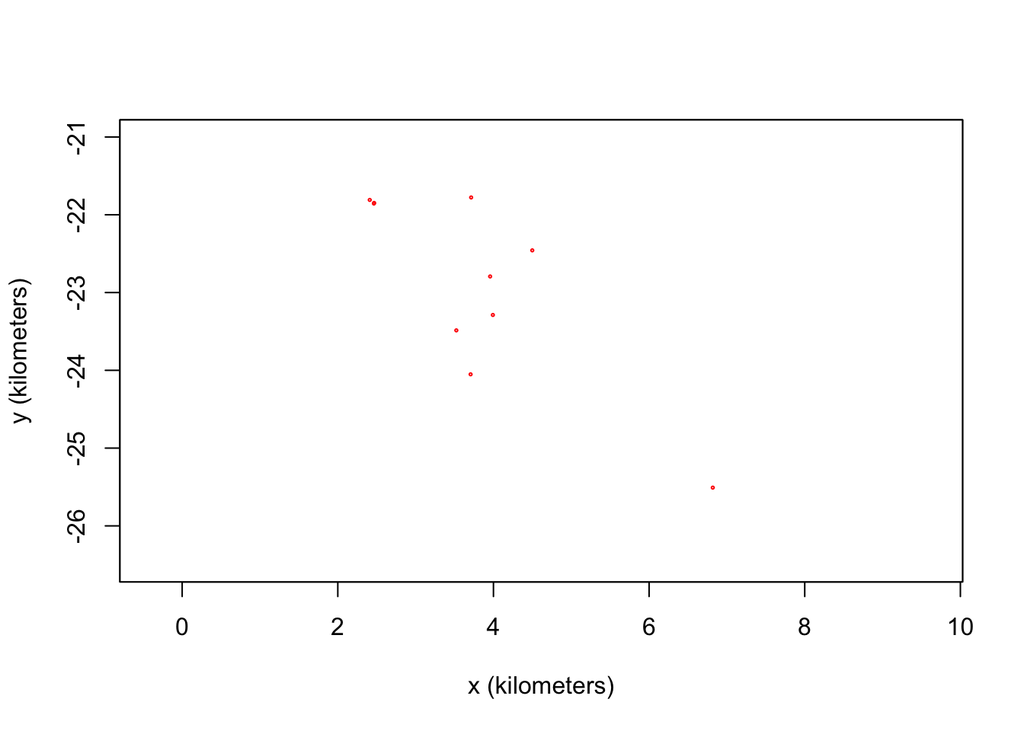

```r
# Take the first 10 locations (first 10 hrs)
SUB <- DATA[1:10,]

# Plot subset
plot(SUB, ylim = c(-26500,-21000))
```

Usually, if working with this little data, small sample size (absolute and effective sample sizes) is a concern for the analysis. You may want to consider using alternative information criteria (IC) to evaluate model performance for the model selection step. For small amounts of data, we recommend using leave-one-out cross-validation (`IC = "LOOCV"` in the `ctmm.select` function). Here, we are just subsetting for the purpose of visualization and to keep the module length to a minimum, so we will not be re-doing model selection with leave-one-out cross-validation.

```r
# If working with this amount of data, you might consider alternative ICs
## in particular IC = "LOOCV"
help("ctmm.select")
```

Say we want to fill in the 1-hour gaps between sampled locations. We can predict where the animal was, by interpolating from the best-fit movement model for the data. We will predict a location for every 5 minutes over the same sampling interval (10 hours). Remember that the `t` column in our telemetry object is time in seconds, so we will need to use the conversion function (`%#%`) to convert 5 minutes to seconds.

```r
# Convenient conversion function (help("%#%"))
1 %#% 'hr'
```

```
## [1] 3600
```

```r
# Make an array of times over the same period, but 5 min apart
SEQ <- seq(from = SUB$t[1], to = SUB$t[10], by = 5 %#% 'min')
```

> The `predict` function in `ctmm` can be used to predict animal locations over a prescribed set of times (as we have done above). The predictions are conditional on the given CTMM movement model.

We will use our best-fit model for Cilla (OUF anisotropic) to interpolate within our 10-hr subset of the data. This can help us reconstruct the potential path taken by Cilla during that sampling period, given the movement model and her data.

```r
help('predict.ctmm')  # makes conditional predictions based on movement/location data
```

There are 3 options for supplying times for location predictions. The `dt` and `res` arguments both maintain the same sampling duration for the data (10 hours in this case), while interpolating; use `dt` to set the absolute (exact) time step to separate predictions, and use `res` to set an average number of locations to predict, where time steps will be relative to the data. The `t` argument allows you to provide a specific array of times over which to predict or simulate.

```
## DOP values missing. Assuming DOP=1.
```

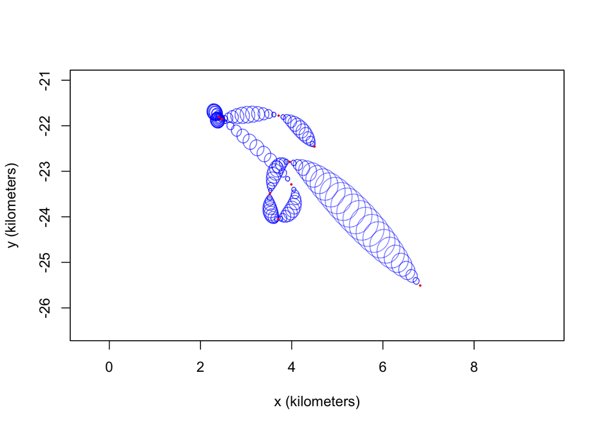

```r
# Predict locations at those times
PRED <- predict(SUB, FIT, t = SEQ)  # predict for every 5 mins
## can allow smoothing for better location estimates
## (for when data points have greater or lesser uncertainty)

# Plot predictions & data
plot(list(PRED, SUB), col = c('blue','red'), ylim = c(-26500,-21000))
```

```r
## uncertainty ellipses
```

As seen in the plot of the predictions above, our actual data is plotted in red, while the predictions are shown as blue ellipses. These are spaced 5 mins apart in time. The **size** of the ellipse represents *prediction uncertainty*. We are more certain about where an animal was when closer in time to the recorded data points, and we are the least certain (largest uncertainty ellipse) about the midpoint between two recorded locations, because the potential locations the individual could have occupied are the greatest at that point in time. The magnitude of our uncertainty in the prediction also depends on the time interval between recorded locations.

```r
# Plot most-likely path
plot(list(PRED, SUB), col = c('gray','red'), ylim = c(-26500,-21000))
```

```
## DOP values missing. Assuming DOP=1.
```

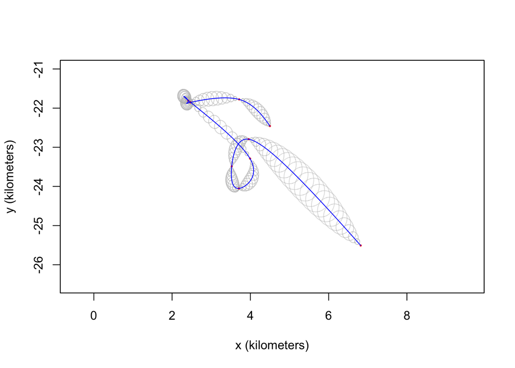

```r
plot(PRED, error = FALSE, type = "l", col = "blue", add = TRUE)
```

> The **most-likely path (MLP)** taken by the individual, given the model, is the path that passes through the center of each error ellipse.

## 5 Simulating Animal Movement

A simulation represents one possible realization of events, given the model and model parameters used to generate it. Simulations are stochastic, so each simulation will be unique. We can either produce:

- **Conditional simulations**, that are informed by movement data and the continuous-time movement model fitted to that data, or,
- **Generic simulations**, using a model we set ourselves that is not informed by real-world data.

In this section, we will explore how each type of simulation can be used and walk through how we can use the `simulate` function in `ctmm` to perform both.

### 5.1 Conditional Simulations

Simulations can be conditioned on a fitted movement model and tracking data (here, African buffalo data). Let’s generate random simulations for the potential paths that Cilla could have taken. Note that when referring to random simulations, the term “random” does not mean completely random without structure; the simulated trajectory is generated with the known location points and given model parameters, such as position autocorrelation ($\tau_p$) and velocity autocorrelation ($\tau_v$).

> There is some *variation in simulated trajectories* based on the data. This variance would match up with the error ellipses. If conditioned on location data, simulations will always pass through the known locations.

```r
help('simulate.ctmm')  # simulate things freely or conditional on data
```

We will use the same 10-hr subset of Cilla’s data to run multiple simulations to get trajectories based on a 1-minute sampling interval.

```
## DOP values missing. Assuming DOP=1.
```

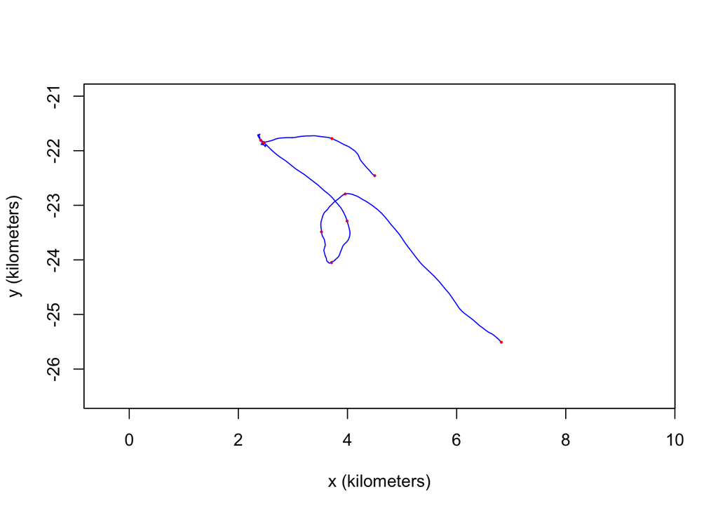

```r
# 1 minute sequence
SEQ <- seq(from = SUB$t[1], to = SUB$t[10], by = 1 %#% 'min')

# Simulate locations at those time (simulation 1)
SIM <- simulate(SUB, FIT, t = SEQ)  # simulate path for every min

# Plot conditional simulation & data
plot(list(SIM, SUB), col = c('blue','red'), type = c('l','p'),
     ylim = c(-26500,-21000))
```

```
## DOP values missing. Assuming DOP=1.
```

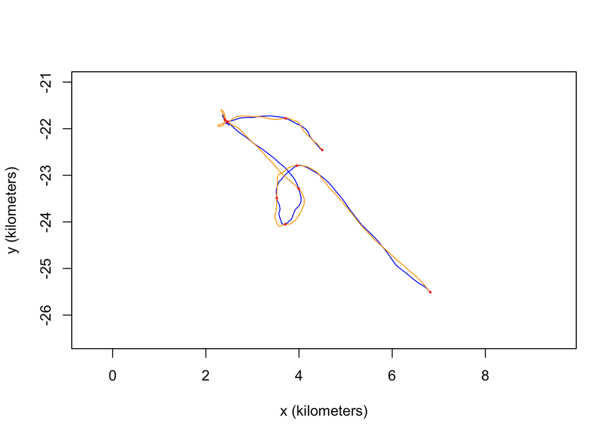

```r
# Simulate again (simulation 2)
SIM2 <- simulate(SUB, FIT, t = SEQ)

# Plot conditional simulation & data
plot(list(SIM, SIM2, SUB), col = c('blue','orange','red'), type = c('l','l','p'),
     ylim = c(-26500,-21000))
```

```r
## some variation in simulated trajectories based on the data
```

The simulations above only include *trajectory uncertainty*. What if we also wan to include *parameter uncertainty* (variation in the model parameters)? We can use the `emulate` function in `ctmm` to simulate the movement model itself from the posterior estimate of a movement model. This assumes that the movement model in not known and we sample from the posterior to approximate the movement model (our `FIT` serves as a guide for sampling parameters).

```r
# We can also include parameter uncertainty
help('emulate')  # simulating movement model itself from posterior of estimate of movement model
```

```
## DOP values missing. Assuming DOP=1.
```

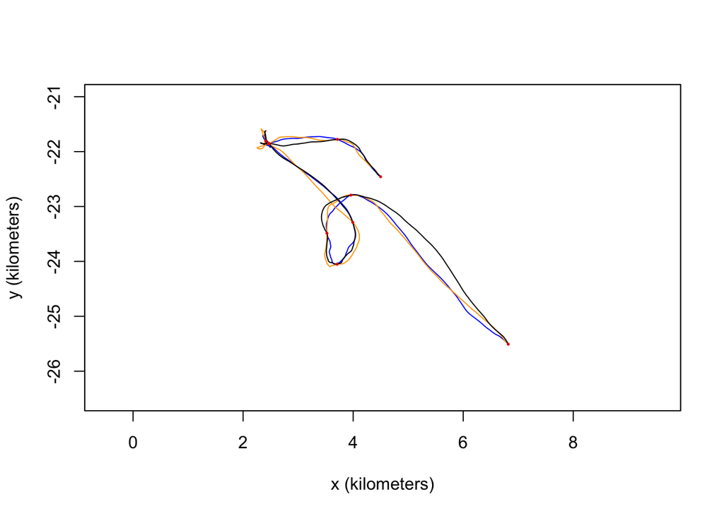

```r
# Include parameter uncertainty
SIM3 <- simulate(SUB, emulate(FIT, fast = T), t = SEQ)
## emulate(FIT) for sample movement model to approximate unknown movement model

plot(list(SIM, SIM2, SIM3, SUB),
     col = c('blue','orange','black','red'), type = c('l','l','l','p'),
     ylim = c(-26500,-21000))
```